# Relacion precio medio (PM) y demanda con variables temporales (hora, dia, …)

# Los resultados indican que los meses con media de precio mas elevado son setiembre, octubre, noviembre y diciembre. Por el contrario, los meses con precios medios mas bajos son febrero, marzo y abril. Respecto a la desviacion estandar, esta es mas pronunciada en enero y febrero (es decir, durante enero y febrero, los precios varian mas respecto a la media)

```r
#Calculamos medias y desviaciones por mes
Month<-electricity_prices$Month
p_m<-data.frame(PM, Month)
summarySE <- function(data=NULL, measurevar, groupvars=NULL, na.rm=FALSE,
                      conf.interval=.95, .drop=TRUE) {
    library(plyr)
    # New version of length which can handle NA's: if na.rm==T, don't count them
    length2 <- function (x, na.rm=FALSE) {
        if (na.rm) sum(!is.na(x))
        else       length(x)
    }
    # This does the summary. For each group's data frame, return a vector with
    # N, mean, and sd
    datac <- ddply(data, groupvars, .drop=.drop,
      .fun = function(xx, col) {
        c(N    = length2(xx[[col]], na.rm=na.rm),
          mean = mean   (xx[[col]], na.rm=na.rm),
          sd   = sd     (xx[[col]], na.rm=na.rm)
        )
      },
      measurevar
    )
    # Rename the "mean" column
    datac <- rename(datac, c("mean" = measurevar))
    datac$se <- datac$sd / sqrt(datac$N)  # Calculate standard error of the mean
    # Confidence interval multiplier for standard error
    # Calculate t-statistic for confidence interval:
    # e.g., if conf.interval is .95, use .975 (above/below), and use df=N-1
    ciMult <- qt(conf.interval/2 + .5, datac$N-1)
    datac$ci <- datac$se * ciMult
    return(datac)
}
library(plyr)
library(ggplot2)
s_month <- summarySE(p_m, measurevar="PM", groupvars=c("Month"))
s_month
```

| Month | N | PM | sd | se | ci |
| --- | --- | --- | --- | --- | --- |
| 1 | 2976 | 47.84195 | 22.263150 | 0.4081033 | 0.8001934 |
| 2 | 2712 | 33.67461 | 19.830011 | 0.3807835 | 0.7466553 |
| 3 | 2975 | 34.95638 | 14.109658 | 0.2586860 | 0.5072218 |
| 4 | 2880 | 34.74347 | 14.300988 | 0.2664832 | 0.5225171 |
| 5 | 2976 | 39.95140 | 12.309179 | 0.2256382 | 0.4424227 |
| 6 | 2880 | 48.34906 | 10.150809 | 0.1891492 | 0.3708815 |
| 7 | 2976 | 48.72855 | 9.531325 | 0.1747177 | 0.3425797 |
| 8 | 2976 | 47.97956 | 8.916729 | 0.1634516 | 0.3204896 |
| 9 | 2880 | 50.58779 | 9.441668 | 0.1759351 | 0.3449715 |
| 10 | 2232 | 52.31577 | 11.793530 | 0.2496300 | 0.4895313 |

[output cut: 2 more lines]

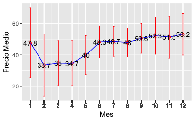

```r
#Realizamos grafico con mean y sd
pd <- position_dodge(0.1)
ggplot(s_month, aes(x=Month, y=PM)) +
    geom_errorbar(aes(ymin=PM-sd, ymax=PM+sd), colour="red", width=.1, position=pd) +
    geom_path(position=pd, color="blue") +
    xlab("Mes") +
    ylab("Precio Medio") +
    geom_point(position=pd, size=1.5, shape=21,color="red") +
    geom_text(aes(label = round(PM, 1)), color="black", size=3.75) +
    scale_x_continuous(breaks=Month)
```

```r
NA
```

```r
library(gplots)
```

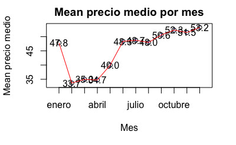

```r
#Realizamos un grafico con la media y los intervalos de confianza por mes y precio medio
plotmeans(PM~Mes, digits=1, ccol="red", mean.labels=TRUE, bars=T, xlab= "Mes",n.label=F, ylab= "Mean precio medio", main="Mean precio medio por mes")
```

```r
#Realizamos test ANOVA para ver si existe una relacion de independencia entre el precio y los meses
anova_mes = aov(PM ~ Mes, data= electricity_prices)
summary(anova_mes)
```

```
               Df  Sum Sq Mean Sq F value Pr(>F)
Mes            11 1602010  145637   755.7 <2e-16 ***
Residuals   32843 6329527     193
---
Signif. codes:  0 '***' 0.001 '**' 0.01 '*' 0.05 '.' 0.1 ' ' 1
```

```r
#Obtenemos el valor critico de una distribucion Fisher con una probabilidad de 5%
qf(0.05, 12-1, 32855-12, lower.tail = F)
```

```
[1] 1.78894
```

# 2.3.2. Demanda - Mes

```r
#Observamos los precios medios por mes
tapply(ep$dem, electricity_prices$Mes, mean)
```

```
    enero   febrero     marzo     abril      mayo     junio     julio    agosto setiembre   octubre noviembre diciembre
 30015.37  30450.67  28497.30  26560.31  26545.25  28383.52  30044.20  28357.28  28172.81  26599.47  27960.04  28589.01
```

La demanda es superior en los meses de enero, febrero y julio

```r
#Realizamos test ANOVA para ver si existe una relacion de independencia entre la demanda y los meses
anova_dm = aov(dem ~ Mes, data= electricity_prices)
summary(anova_dm)
```

```
               Df    Sum Sq   Mean Sq F value Pr(>F)
Mes            11 5.510e+10 5.010e+09   261.4 <2e-16 ***
Residuals   32843 6.295e+11 1.917e+07
---
Signif. codes:  0 '***' 0.001 '**' 0.01 '*' 0.05 '.' 0.1 ' ' 1
```

```r
#Obtenemos el valor critico de una distribucion Fisher con una probabilidad de 5%
qf(0.05, 12-1, 32855-12, lower.tail = F)
```

```
[1] 1.78894
```

Con un valor F muy superior al valor critico, rechazamos la hipotesis nula de que no hay diferencia significativa entre la media de los distintos meses

[figure not shown]

```r
plotmeans(electricity_prices$dem~Mes, digits=2, ccol="red", mean.labels=TRUE, bars=T, xlab= "Mes", ylab= "Mean demanda", p=0.95, main="Mean plot demanda por mes")
```

Observamos que los valores mas bajos se producen en abril, mayo y octubre

# 2.4 Analisis precio por semana del mes

```r
#Analisis de correlaciones entre la variable precio MD, semana mes
cor(PM, electricity_prices$WeekofMonth)
```

```
[1] 0.04044451
```

```r
#Analisis precio medio por semana mes
tapply(PM, electricity_prices$WeekofMonth, mean)
```

```
       1        2        3        4        5
43.30977 45.11485 45.30276 45.65353 45.14844
```

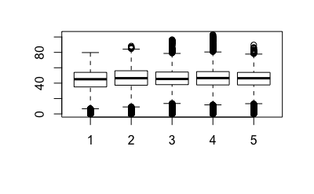

```r
#Analisis precio medio por semana mes
boxplot(PM~electricity_prices$WeekofMonth)
```

# No parece haber relacion entre la semana del mes y el precio de la electricidad

# 2.3. Analisis bivarial precio demanda

```r
#Correlacion precio y demanda
round(cor(electricity_prices$dem, PM),4)
```

```
[1] 0.4472
```

El precio y la demanda parecen mantener una relacion positiva

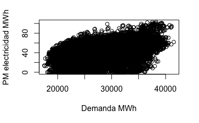

```r
#Analisis visual relacion precio demanda mediante scatter plot
plot(electricity_prices$dem, PM, ylab = "PM electricidad MWh", xlab= "Demanda MWh")
```

```r
#Realizamos regresion y comprobamos la normalidad
price_dem.lm = lm(electricity_prices$PM ~ electricity_prices$dem  , data=electricity_prices)
price_dem.lm
```

```
Call:
lm(formula = electricity_prices$PM ~ electricity_prices$dem,
    data = electricity_prices)

Coefficients:
           (Intercept)  electricity_prices$dem
              1.732515                0.001522
```

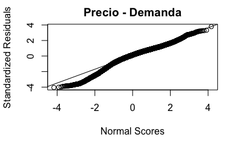

```r
price_dem.stdres = rstandard(price_dem.lm)
qqnorm(price_dem.stdres,
       ylab="Standardized Residuals",
       xlab="Normal Scores",
       main="Precio - Demanda")
qqline(price_dem.stdres)
```

Con el estudio de los residuos podemos ver que la relacion no presenta normalidad

```r
summary(price_dem.lm)
```

```
Call:
lm(formula = electricity_prices$PM ~ electricity_prices$dem,
    data = electricity_prices)

Residuals:
    Min      1Q  Median      3Q     Max
-56.262  -7.206   1.889   9.459  52.600

Coefficients:
                        Estimate Std. Error t value Pr(>|t|)
(Intercept)            1.7325146  0.4828218   3.588 0.000333 ***
electricity_prices$dem 0.0015221  0.0000168  90.618  < 2e-16 ***
---
Signif. codes:  0 '***' 0.001 '**' 0.01 '*' 0.05 '.' 0.1 ' ' 1

Residual standard error: 13.9 on 32853 degrees of freedom
Multiple R-squared:    0.2, Adjusted R-squared:  0.1999
F-statistic:  8212 on 1 and 32853 DF,  p-value: < 2.2e-16
```

El valor de R-squared es muy bajo, lo que demuestra la poca relacion lineal entre las variables.

```r
#A??adimos la linea de regresi??n al grafico
plot(electricity_prices$dem, electricity_prices$PM, xlab = "Demanda MWh", ylab = "Precio medio euros MWh")
abline(lm(electricity_prices$PM ~ electricity_prices$dem), col= "red")
```

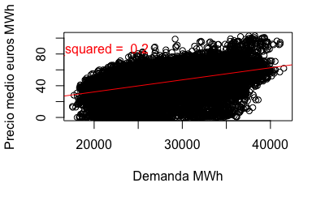

```r
text(20500, 85, labels = "R_squared =  0.2", col = "red")
```

```r
#Realizamos una transformacion en la variable demanda (elevamos al cuadrado)
ep_dem<-electricity_prices[,c("PM", "dem")]
ep_dem$dem_SQ<-electricity_prices$dem^2
cor(ep_dem)
```

```
              PM       dem    dem_SQ
PM     1.0000000 0.4471792 0.4423939
dem    0.4471792 1.0000000 0.9965004
dem_SQ 0.4423939 0.9965004 1.0000000
```

```r
#Realizamos regresion con la funcion cuadratica
PM2_dem.lm <- lm(electricity_prices$PM ~ electricity_prices$dem + I(electricity_prices$dem^2), data=electricity_prices)
summary(PM2_dem.lm)
```

```
Call:
lm(formula = electricity_prices$PM ~ electricity_prices$dem +
    I(electricity_prices$dem^2), data = electricity_prices)

Residuals:
    Min      1Q  Median      3Q     Max
-55.215  -7.192   1.805   9.470  52.040

Coefficients:
                              Estimate Std. Error t value Pr(>|t|)
(Intercept)                 -1.999e+01  2.821e+00  -7.085 1.42e-12 ***
electricity_prices$dem       3.085e-03  2.008e-04  15.368  < 2e-16 ***
I(electricity_prices$dem^2) -2.741e-08  3.508e-09  -7.814 5.69e-15 ***
---
Signif. codes:  0 '***' 0.001 '**' 0.01 '*' 0.05 '.' 0.1 ' ' 1

Residual standard error: 13.89 on 32852 degrees of freedom
Multiple R-squared:  0.2015,    Adjusted R-squared:  0.2014
F-statistic:  4144 on 2 and 32852 DF,  p-value: < 2.2e-16
```

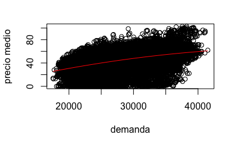

```r
#A??adimos la linea de regresi??n al grafico
plot(electricity_prices$dem, electricity_prices$PM, xlab = "demanda", ylab = "precio medio")
curve(PM2_dem.lm$coefficient[1]+PM2_dem.lm$coefficient[2]*x+PM2_dem.lm$coefficient[3]*x^2,add=T,col="red")
```